# Final Project 2 Report

Jasmine Robinson

2026-10-01

## Introduction

The heart disease data set contains information on 270 patients. The data includes patient characteristics and health metrics such as age, sex, chest pain type, resting blood pressure, cholesterol, maximum heart rate, and whether heart disease is present.

This analysis looks at characteristics of the patients in the data set and examines how health metrics differ between patients with and without heart disease. I will look at age, cholesterol, resting blood pressure, and maximum heart rate.

## Description of the Data

Table 1 summarizes characteristics of the patients by heart disease status. It compares patients with and without heart disease using age, sex, resting blood pressure, cholesterol, and maximum heart rate. The table also includes an overall summary for all patients and p values that compare the two heart disease groups.

| **Characteristic** | **Overall** N = 270<sup>1</sup> | **Heart Disease Status** **Absent** N = 150<sup>1</sup> | **Heart Disease Status** **Present** N = 120<sup>1</sup> | **p-value**<sup>2</sup> |  |
| --- | --- | --- | --- | --- | --- |
| Age | 55 (48, 61) | 52 (45, 59) | 58 (52, 62) |  | <0.001 |
| Sex |  |  |  | <0.001 |  |
| Female | 87 (32%) | 67 (45%) | 20 (17%) |  |  |
| Male | 183 (68%) | 83 (55%) | 100 (83%) |  |  |
| Resting blood pressure | 130 (120, 140) | 130 (120, 140) | 130 (120, 145) | 0.032 |  |
| Cholesterol | 245 (213, 281) | 236 (209, 269) | 256 (227, 287) | 0.008 |  |
| Maximum heart rate | 154 (133, 166) | 161 (148, 172) | 142 (125, 158) | <0.001 |  |

<sup>1</sup> Median (Q1, Q3); n (%)  
<sup>2</sup> Wilcoxon rank sum test; Pearson’s Chi-squared test

## Distribution of Cholesterol Figure

The histogram shows the distribution of cholesterol measurements across patients. Most cholesterol values are concentrated around the middle of the distribution, while theres a small amount of patients have much higher cholesterol measurements.

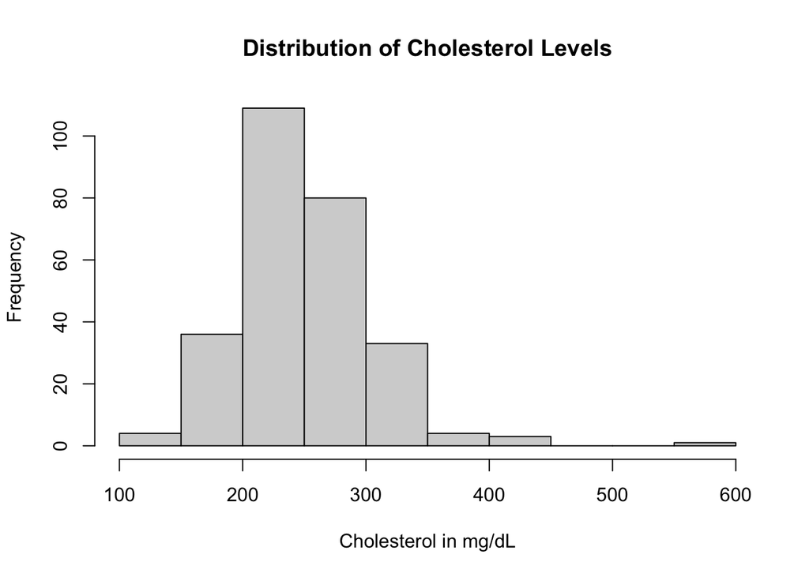

## Heart Disease and Maximum Heart Rate Figure

The figure shows that patients with heart disease have lower maximum heart rates than patients without heart disease. This difference is numerically shown in the summary table above.

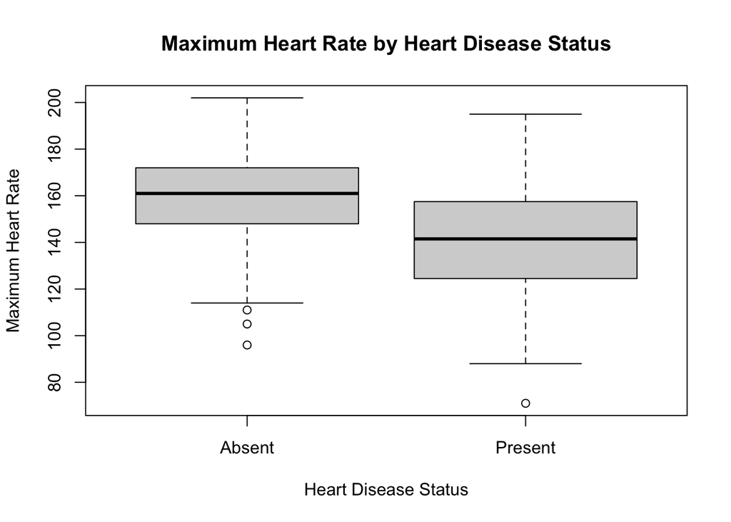